# Geospatial data and the R ecosystem

April 1, 2015

## Background

## Analysis of geospatial data in R

R has a rich package ecosystem for read/writing, manipulating, and analyzing geospatial data.

Some core packages:

- `sp` - core classes for handling spatial data, additional utility functions.
- `rgdal` - R interface to `gdal` (Geospatial Data Abstraction Library) for reading and writing spatial data.
- `maptools` - Additional tools for reading and writing spatial data.
- `rgeos` - R interface to `geos` (Geometry Engine Open Source) library for querying and manipulating spatial data. Reading and writing WKT.
- `raster` - classes and tools for handling spatial raster data.

See more - [Spatial task view](http://cran.r-project.org/web/views/Spatial.html)

## Taxonomy of geospatial objects (Simple Features)

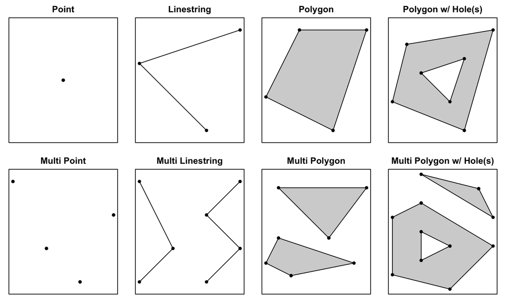

## Geometry Collection

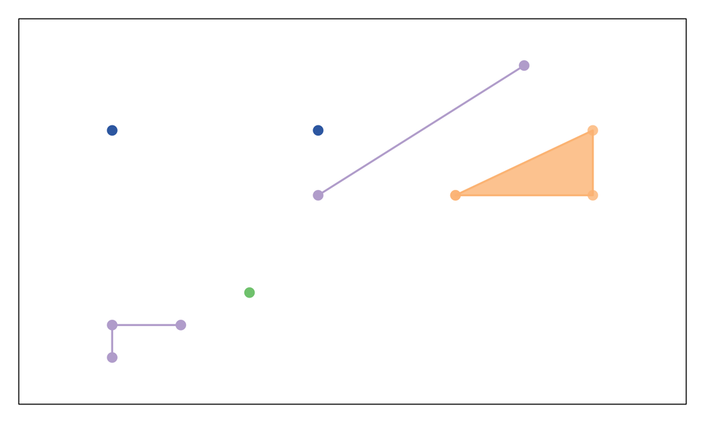

## R and Simple Feature Access

The R package `sp` provides classes that implement these geospatial objects.

|  | Point(s) | Linestring(s) | Polygon(s) | Geometry Collection |
| --- | --- | --- | --- | --- |
| Geometry | `SpatialPoints` | `SpatialLines` | `SpatialPolygons` | `SpatialCollection`* |
| Geometry + Data | `SpatialPointsDataFrame` | `SpatialLinesDataFrame` | `SpatialPolygonsDataFrame` | — |

They also handle additional tasks like tracking the projection of the spatial coordinates.

## Reading and writing geospatial data via `sp`

- `maptools`:
  - `readShapePoints` / `writeShapePoints` - Shapefile w/ points
  - `readShapeLines` / `writeShapeLines` - Shapefile w/ lines
  - `readShapePoly` / `writeShapePoly` - Shapefile w/ polygons
  - `readShapeSpatial` / `writeShapeSpatial` - Shapefile
- `rgdal`:
  - `readOGR` / `writeOGR` - Shapefile, GeoJSON, KML, …
- `rgeos`:
  - `readWKT` / `writeWKT` - Well Known Text

## Geospatial stuff is hard

## Projections

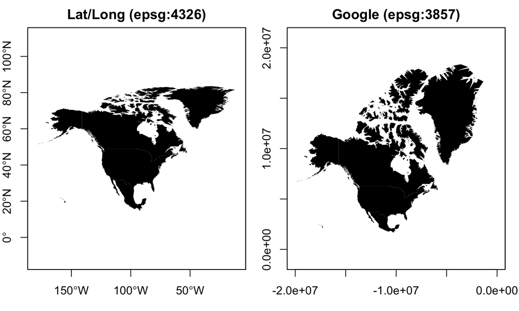

## Dateline

Want to fly from the Western most point in the US to the Eastern most point?

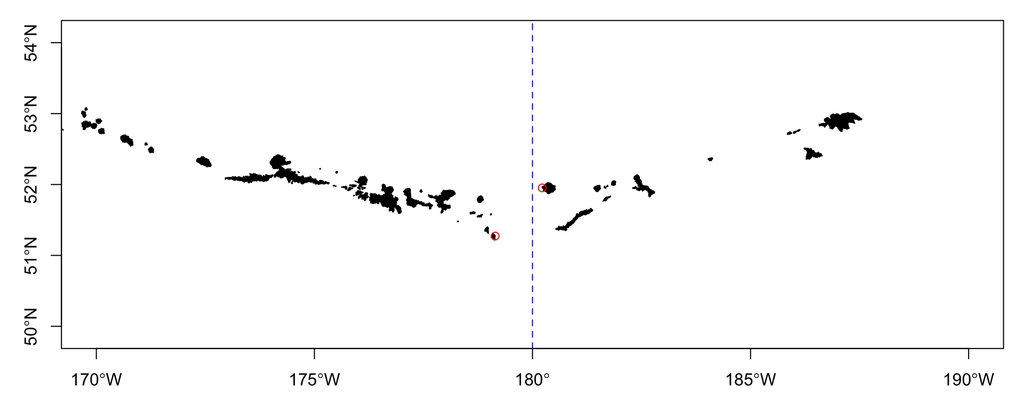

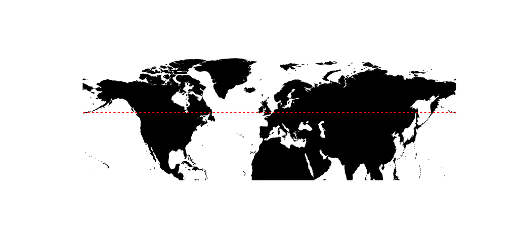

```r
inter = gcIntermediate(c(179.776,51.952), c(-179.146,51.273), n=50, addStartEnd=TRUE)

plot(wrld_simpl, col="black", ylim=c(15,90))
lines(inter,col='red',lwd=2,lty=3)
```

## Relationships

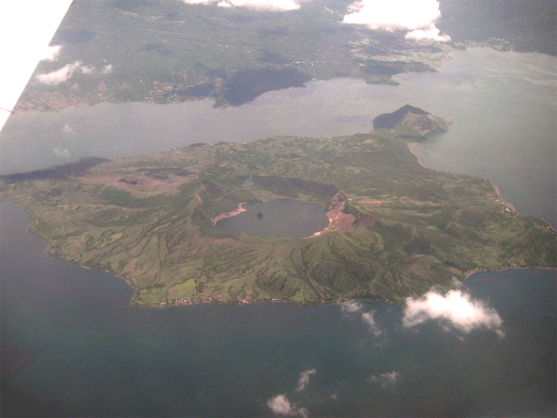

## Distance

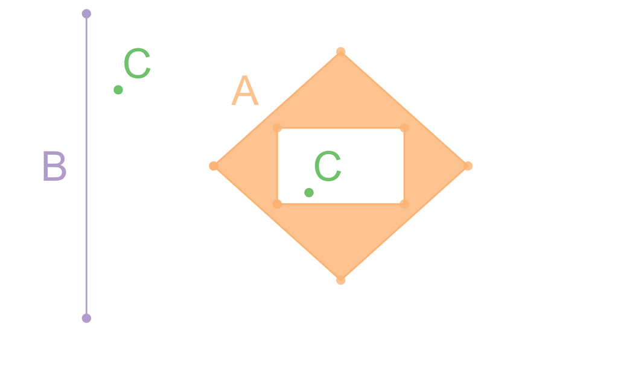

How do we define the distance between A and B, A and C, or B and C?

## GIS Functionality

## Example data

```r
nc  = readOGR("data/nc_counties/","nc_counties",FALSE)
air = readOGR("data/airports/","airports",FALSE)
hwy = readOGR("data/us_interstates/","us_interstates",FALSE)

proj4string(nc)
```

```
## [1] "+proj=longlat +datum=NAD83 +no_defs +ellps=GRS80 +towgs84=0,0,0"
```

```r
proj4string(air)
```

```
## [1] "+proj=longlat +datum=NAD83 +no_defs +ellps=GRS80 +towgs84=0,0,0"
```

```r
proj4string(hwy)
```

```
## [1] "+proj=utm +zone=15 +datum=NAD83 +units=m +no_defs +ellps=GRS80 +towgs84=0,0,0"
```

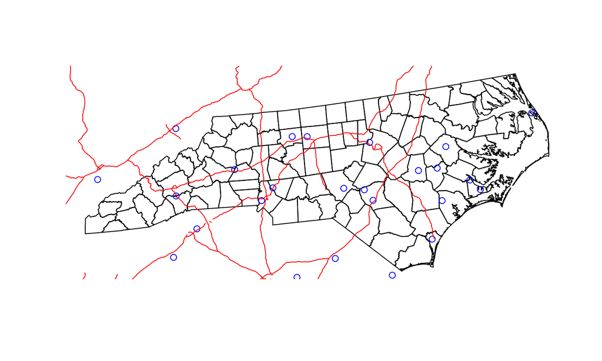

```r
nc = spTransform(nc, CRS(proj4string(hwy)))
row.names(nc) = sub(" County","", as.character(nc$COUNTY))
air = spTransform(air, CRS(proj4string(hwy)))

plot(nc)
plot(air, add=TRUE, pch=1, col="blue")
plot(hwy, add=TRUE, col="red")
```

## Distance to the closest airport from each county?

```r
d = gDistance(nc,air,byid=c(TRUE,FALSE))
str(d)
```

```
##  num [1, 1:100] 56851 71272 24297 49802 19809 ...
##  - attr(*, "dimnames")=List of 2
##   ..$ : NULL
##   ..$ : chr [1:100] "Ashe" "Alleghany" "Surry" "Gates" ...
```

```r
d[,"Durham"]
```

```
##  Durham
## 3334.51
```

```r
d[,"Wake"]
```

```
## Wake
##    0
```

```r
d[,"Orange"]
```

```
##   Orange
## 20633.96
```

## Distance to County centroid?

```r
ncc = gCentroid(nc,byid=TRUE)
class(ncc)
```

```
## [1] "SpatialPoints"
## attr(,"package")
## [1] "sp"
```

```r
d = gDistance(ncc,air,byid=c(TRUE,FALSE))
```

```r
d[,"Durham"]
```

```
##   Durham
## 19685.62
```

```r
d[,"Wake"]
```

```
##     Wake
## 16071.85
```

```r
d[,"Orange"]
```

```
##   Orange
## 37003.97
```

## Spatial predicates in `rgeos`

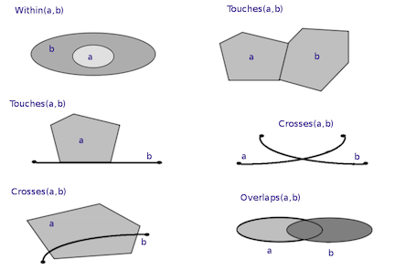

For more detail see the DE-9IM specification

## Which counties have airports?

```r
nc_air = gIntersects(nc,air,byid=c(TRUE))
str(nc_air)
```

```
##  logi [1:940, 1:100] FALSE FALSE FALSE FALSE FALSE FALSE ...
##  - attr(*, "dimnames")=List of 2
##   ..$ : chr [1:940] "1" "2" "3" "4" ...
##   ..$ : chr [1:100] "Ashe" "Alleghany" "Surry" "Gates" ...
```

```r
nc$COUNTY[apply(nc_air,2,any)]
```

```
##  [1] Forsyth County     Guilford County    Dare County
##  [4] Wake County        Pitt County        Catawba County
##  [7] Buncombe County    Wayne County       Mecklenburg County
## [10] Moore County       Cabarrus County    Lenoir County
## [13] Craven County      Cumberland County  Onslow County
## [16] New Hanover County
## 100 Levels: Alamance County Alexander County ... Yancey County
```

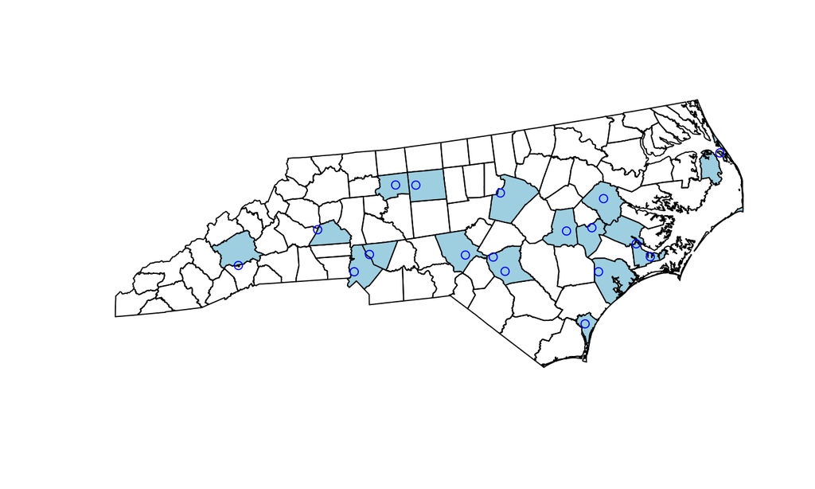

```r
plot(nc)
plot(nc[apply(nc_air,2,any),], add=TRUE, col="lightblue")
plot(air[apply(nc_air,1,any),], add=TRUE, pch=1, col="blue")
```

## Adjacency matrix of counties

```r
adj = gTouches(nc,byid=TRUE)
str(adj)
```

```
##  logi [1:100, 1:100] FALSE TRUE FALSE FALSE FALSE FALSE ...
##  - attr(*, "dimnames")=List of 2
##   ..$ : chr [1:100] "Ashe" "Alleghany" "Surry" "Gates" ...
##   ..$ : chr [1:100] "Ashe" "Alleghany" "Surry" "Gates" ...
```

```r
nc$COUNTY[adj["Durham",]]
```

```
## [1] Person County    Granville County Orange County    Wake County
## [5] Chatham County
## 100 Levels: Alamance County Alexander County ... Yancey County
```

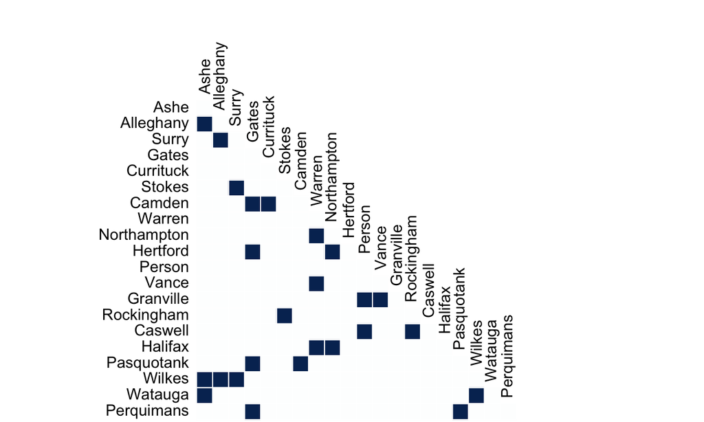

```r
library(corrplot)
corrplot(adj[1:20,1:20],method="color",type="lower",tl.col="black",cl.pos = "n")
```

## Which counties have the most neighbors?

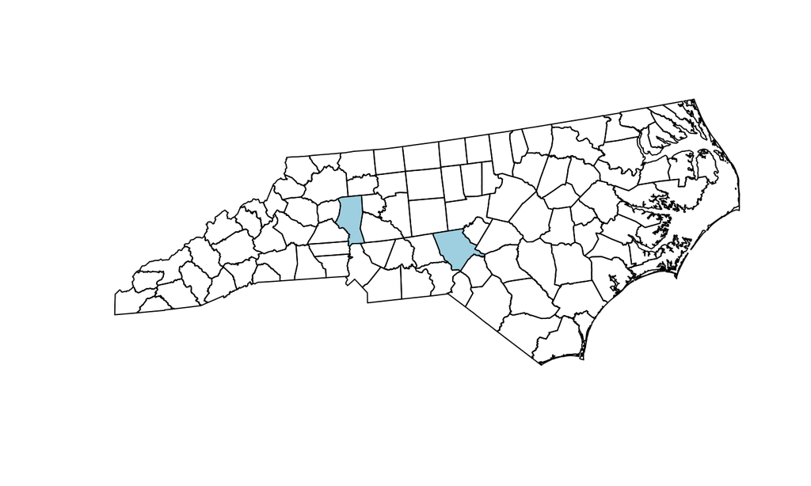

```r
plot(nc)
plot(nc[rowSums(adj)==max(rowSums(adj)),],add=TRUE,col="lightblue")
```

## Which counties have the least neighbors?

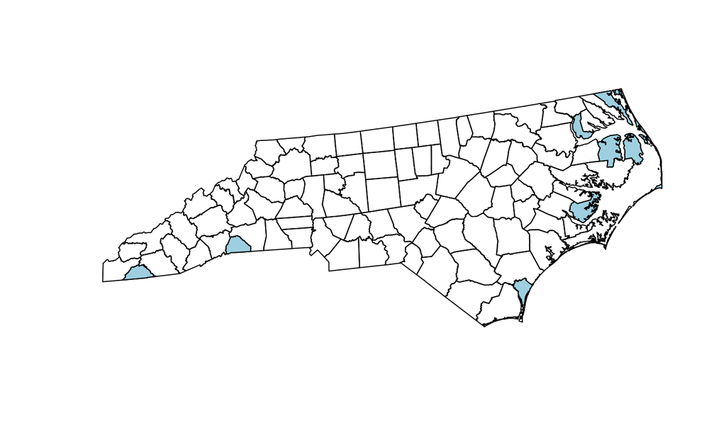

```r
plot(nc)
plot(nc[rowSums(adj)==min(rowSums(adj)),],add=TRUE,col="lightblue")
```

## Conclusion

## Summary

- Geospatial stuff can be hard … but it doesn't have to be
  - Don't reinvent the wheel
  - Open standards are your friend
  - High quality open source libraries
- Keep calm, use R
  - Built on the same standards compliant libraries
  - Open source with a vibrant and growing package ecosystem
  - Reproducibility via scriptability
  - Unification of workflow

Questions & Comments?

| email |  | rundel@gmail.com |
| --- | --- | --- |
| github |  | http://github.com/rundel |
| presentation |  | http://bit.ly/1MCKNzK |